# Desafio 14

Author

Julia Folgueral - RA: 277178

```
Este arquivo foi gerado em: 30/10/2025 19:08:35
```

```r
library(reticulate)
virtualenv_create("env1")
```

```
virtualenv: env1
```

```r
use_virtualenv("env1")
```

```r
py_install("polars", envname = "env1")
```

```
Using virtual environment "env1" ...
```

```
+ "C:/Users/Marcia/Documents/.virtualenvs/env1/Scripts/python.exe" -m pip install --upgrade --no-user polars
```

```r
py_install("plotnine", envname = "env1")
```

```
Using virtual environment "env1" ...
```

```
+ "C:/Users/Marcia/Documents/.virtualenvs/env1/Scripts/python.exe" -m pip install --upgrade --no-user plotnine
```

1. Importe o conjunto de dados diamonds, cujo arquivo está disponível no website da disciplina.

```python
from plotnine.data import diamonds

# Ver as primeiras linhas
print(diamonds.head())
```

```
   carat      cut color clarity  depth  table  price     x     y     z
0   0.23    Ideal     E     SI2   61.5   55.0    326  3.95  3.98  2.43
1   0.21  Premium     E     SI1   59.8   61.0    326  3.89  3.84  2.31
2   0.23     Good     E     VS1   56.9   65.0    327  4.05  4.07  2.31
3   0.29  Premium     I     VS2   62.4   58.0    334  4.20  4.23  2.63
4   0.31     Good     J     SI2   63.3   58.0    335  4.34  4.35  2.75
```

2. Crie uma visualização de dados que descreva a associação existente entre as variáveis peso (carat) e preço (price). Que ações você tomou para garantir que você produziu um gráfico de boa qualidade? Escreva um parágrafo comunicando os seus achados.

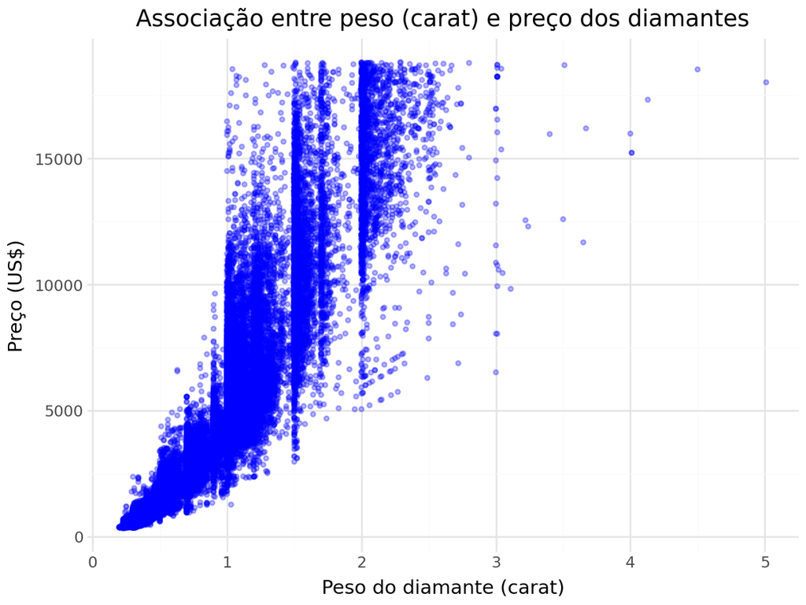

```python
from plotnine import ggplot, aes, geom_point, geom_smooth, labs, theme_minimal
from plotnine.data import diamonds

grafico = (
    ggplot(diamonds, aes(x='carat', y='price')) +
    geom_point(alpha=0.3, color="blue", size=1) +
    #geom_smooth(method='lm', color='red', se=False) +
    labs(
        title='Associação entre peso (carat) e preço dos diamantes',
        x='Peso do diamante (carat)',
        y='Preço (US$)'
    ) +
    theme_minimal()
)

grafico
```

```python
# Salva o gráfico em arquivo (função Python!)
#grafico.save("carat_vs_price.png", dpi=300)
```

Para garantir uma boa qualidade do gráfico foi utilizado transparência (alpha = 0.3) para reduzir a sobreposição de pontos e melhorar a visibilidade da densidade. Além disso, foi escolhida uma boa cor visivelmente, tamanho apropriado para os pontos (size = 1) e um tema minimalista (remove o fundo cinza padrão e destaca a relação entre as variáveis).

Com o gráfico acima, é possível notar que há uma relação de crescimento entre o peso (carat) e o preço dos diamantes, pois conforme o peso aumenta, o preço tende a subir. Essa relação não é perfeitamente linear, dado que o aumento de preço é mais acentuado para diamantes maiores, indicando que o valor cresce de forma mais rápida do que o peso.

3. A relação identificada na questão anterior é a mesma relação presente nos diferentes cortes de diamantes? Crie uma visualização que demonstre seus achados eficientemente. Descreva sua conclusão em um parágrafo.

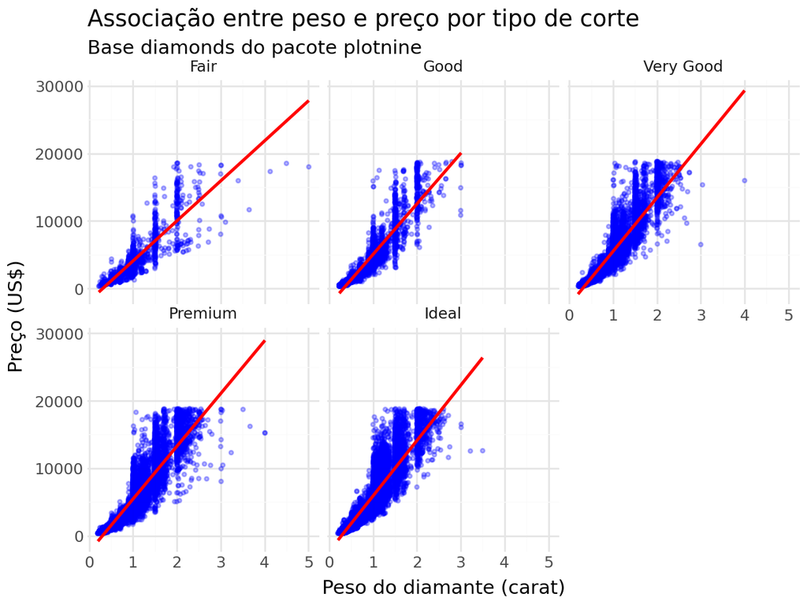

```python
from plotnine import ggplot, aes, geom_point, geom_smooth, facet_wrap, labs, theme_minimal
from plotnine.data import diamonds

grafico_cut = (
    ggplot(diamonds, aes(x='carat', y='price')) +
    geom_point(alpha=0.3, color="blue", size=0.8) +
    geom_smooth(method='lm', color='red', se=False) +
    facet_wrap('~cut') +  # cria um painel para cada tipo de corte
    labs(
        title='Associação entre peso e preço por tipo de corte',
        subtitle='Base diamonds do pacote plotnine',
        x='Peso do diamante (carat)',
        y='Preço (US$)'
    ) +
    theme_minimal()
)

grafico_cut
```

```python
#grafico_cut.save("grafico_cut", dpi=300)
```

Analisando a relação entre peso (quilates) e preço através dos diferentes tipos de corte dos diamantes, observa-se que quanto maior o quilate, maior tende a ser o preço. No entanto, os diamantes com corte “Ideal” e “Very Good” geralmente tem preços mais altos para pesos semelhantes quando comparados com cortes “Good” e “Fair”, especialmente na faixa de 1 a 2 quilates. Esta diferença sugere que cortes maiores agregam mais valor aos diamantes. Ao analisar diamantes muito grandes (acima de 3 quilates), essa distinção entre cortes parece se tornar menos evidente, possivelmente porque o tamanho se torna o fator dominante na determinação do preço.

4. Crie uma visualização que mostre a relação entre preço e peso do diamante, considerando as diferentes combinações de qualidade de corte, cor e clareza do diamante. Quais foram as dificuldades encontradas? A relação entre preço e peso é a mesma para diferentes configurações de diamantes?

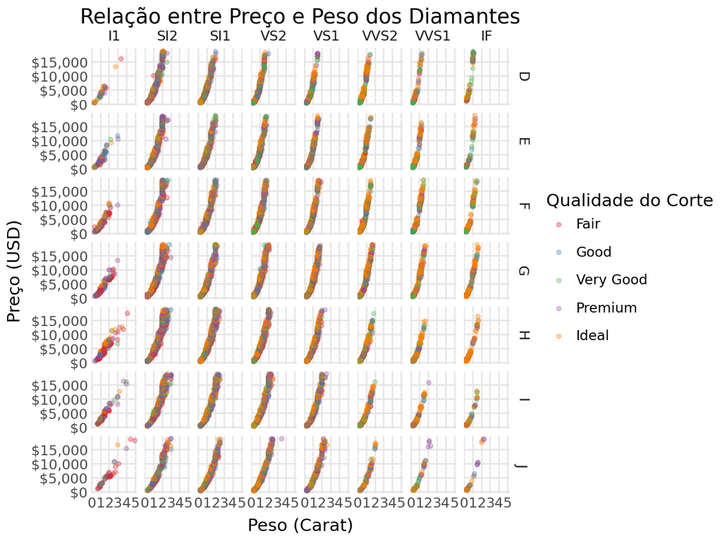

```python
from plotnine import ggplot, aes, geom_point, geom_smooth, facet_grid, labs, theme_minimal, scale_y_continuous, scale_color_brewer


p = (
    ggplot(diamonds, aes(x='carat', y='price', color='cut')) +
    geom_point(alpha=0.3, size=1) +
    #geom_smooth(method='lm', se=False, color='black') +
    facet_grid('color ~ clarity') +
    scale_y_continuous(labels=lambda l: ["${:,.0f}".format(v) for v in l]) +
    scale_color_brewer(type='qual', palette='Set1') +  # paleta mais agradável
    labs(
        title="Relação entre Preço e Peso dos Diamantes",
        x="Peso (Carat)",
        y="Preço (USD)",
        color="Qualidade do Corte"
    ) +
    theme_minimal()
)

p
```

```python
#p.save("grafico_4", dpi=300)
```

A principal dificuldade é relacionar diversas variáveis em um único grafico, de forma que a visualização seja clara. Além disso, as variáveis apresentam várias categorias, tornando a visualização um pouco mais complexa.

A relação entre preço e peso dos diamantes apresenta um crescimento em todos os gráficos, indicando que diamantes mais pesados tendem a ser mais caros independentemente da cor ou pureza. No entanto, diamantes de melhor qualidade de corte (Ideal e Premium) e maior pureza (IF, VVS1 e VVS2) apresentam um aumento de preço mais marcante conforme o peso cresce, enquanto aqueles com cortes de qualidade inferior (*Fair* e *Good*) ou menor pureza (como I1 e SI2) mostram um crescimento mais suave. Assim, mesmo que a tendência seja a mesma, a força da relação entre preço e peso depende diretamente da qualidade e das características do diamante.